# `A. Git`

- Git is a Distributed Version Control System designed to track changes in source code during software development.

Features:

- It is a way to manage files and directories
- It tracks changes in files over time
- Recall previous version
- Easy to revert back to previous files if anything happens
- Ability to have unlimited developers working on the same code base

## `Version Control Systems`:

1. **`Centralized Version Control System (CVCS)`**
2. **`Distributed Version Control System (DVCS)`**

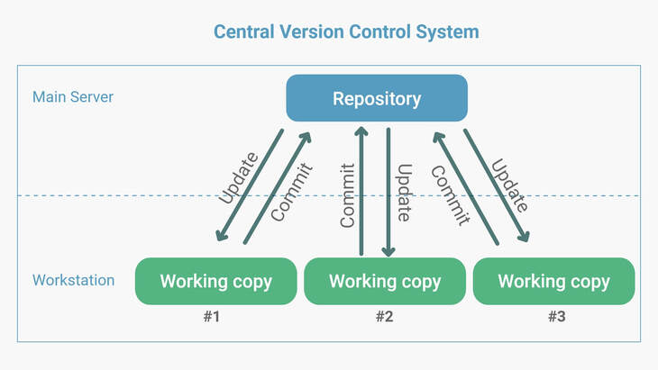

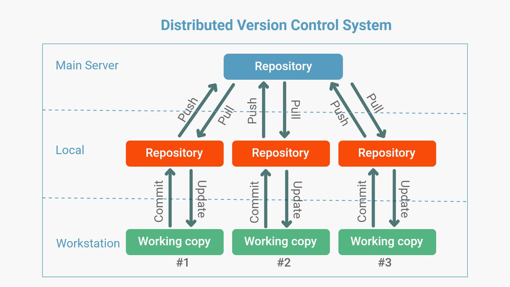

## `Centralized vs Distributed Version Control Systems`

| Feature | CVCS (Centralized VCS) | DVCS (Distributed VCS) |
| --- | --- | --- |
| **Repository Location** | Single central server holds the complete codebase | Every developer has a full copy of the repository |
| **Offline Work** | Limited functionality without server access | Full functionality offline |
| **Performance** | Slower - many operations require server communication | Faster - most operations are local |
| **Branching & Merging** | Often cumbersome and error-prone | Lightweight, fast, and encourages experimentation |
| **Collaboration Model** | Centralized - developers commit directly to the central repo | Decentralized -developers push/pull from each other or remote |
| **Single Point of Failure** | Yes - if the server goes down, work halts | No - every clone is a backup |
| **Learning Curve** | Simpler for beginners | Steeper, but more powerful once mastered |
| **Use Cases** | Small teams, tightly controlled environments | Large teams, open-source projects, distributed contributors |

> 💡 **Analogy**: CVCS is like working on a shared Google Doc, while DVCS is like everyone having their own copy and syncing changes when ready.

## `Common CLI Commands`

| No. | Command / Syntax | Description |
| --- | --- | --- |
| 1 | `pwd` | Present Working Directory |
| 2 | `ls` | List all files (excluding hidden files) |
| 3 | `ls -a` | List all files including hidden files |
| 4a | `ls -al` | List all files including hidden ones with details |
| 4b | `ls -la` | Same as above |
| 4c | `ls -a -l` | Same as above |
| 4d | `ls -l -a` | Same as above |
| 5a | `cd <Directory>/` | Change to specified directory |
| 5b | `cd ..` | Move to parent directory |
| 5c | `cd ..\..` | Move two directories up |
| 6a | `mkdir <Directory_Name>` | Create a directory |
|  | `mkdir GIT` | Example: Creates a folder named `GIT` |
| 6b | `mkdir '<Directory Name>'` | Create directory with spaces in name |
|  | `mkdir 'GIT Class Study'` | Example: Creates folder `GIT Class Study` |
| 6c | `mkdir Dir1 Dir2 Dir3` | Create multiple directories at once |
|  | `mkdir Python 'SQL Class Notes' GIT` | Example: Creates 3 folders |
| 7 | `mv <Source> <Destination>` | Move directory or file |
|  | `mv Python 'SQL Class Notes'` | Example: Moves `Python` into `SQL Class Notes` |
| 8 | `touch <filename>` | Create a new file |
| 9 | `nano <filename>` | Open file in terminal editor (Nano) |
| 10a | `rmdir <Directory_Name>` | Remove empty directory |
| 10b | `rm -r <Directory_Name>` | Remove directory recursively |
| 10c | `rm <filename>` | Remove a file |
| 11 | `vim <filename>` | Open file in Vim editor |
| 12 | `cat <filename>` | Display file contents |
| 13 | `clear` | Clear the terminal screen |
| 14 | `history` | Show command history with index numbers |
|  | `!<index>` | Re-run command from history using its index |

## `Essential Git Commands`

| No. | Command / Syntax | Description |
| --- | --- | --- |
| 1 | `git init` | Initializes a Git repository (creates hidden `.git` folder) |
| 2 | `git config --global user.name "<username>"` | Sets global Git username |
|  | `git config --global user.name "Aniket"` | Example |
| 3 | `git config --global user.email "<emailid>"` | Sets global Git email |
|  | `git config --global user.email "aniketmuthal28@gmail.com"` | Example |
| 4 | `git config --global core.autocrlf true` | Prevents line-ending warnings |
| 5 | `touch <filename>` | Creates a new file |
| 6 | `nano <filename>` | Opens file in Nano editor |
| 7a | `git add .` | Adds all files to staging area |
| 7b | `git add <filename>` | Adds a specific file to staging |
| 8a | `git commit .` | Commits all staged files |
| 8b | `git commit <filename>` | Commits a specific file |
| 9 | `git status` | Displays current status of working directory and staging area |
| 10 | `git diff <filename>` | Shows changes made to a file |
| 11 | `git log` | Displays commit history |
| 12 | `git rm --cached <filename>` | Removes file from staging (keeps it locally) |
| 13 | `git restore <filename>` | Restores file to last committed state |

## `Source Code Management`

- GIT does not track empty folders/directories/repositories. It only tracks files in the folders.
- When we create a file, modify a file or delete a file it is present in the non-staging area.
- Branch is created only during the first commit.
- HEAD is a pointer to the latest commit (However the position of HEAD can be changed at any time).

### `1. git init`

**1.1. `git init`**

- 'git init' command creates *local repository*
- That is, it creates '**`.git`**' folder/directory (local server) which is a hidden file. ('.filename' indicates hidden file)
- Whenever you do 'git init', the default branch that will get created is 'Master'

**1.2. `git init --initial-branch=<branch_name\>`**

- 'git init --initial-branch=main' command changes the branch name to 'main'

**1.3. `rm rf .git`**

- Deletes the local repository

### `2. git status`

**2.1. `git status`**

- 'git status' command is used to check the status of a file
- It tells whether files are in staging area or non-staging area
- If the files are in non-staging area, it highlights the file names in *red* color under the header - '*Untracked files*'
- If we modify an already commited file (files are in non-staging area), 'git status' highlights the file name/folder name in red color under the header '*Changes not staged for commit*'.
- If the files are in staging area but not commited yet, it highlights the file names in *green* color under the header '*Changes to be commited*'
- If the files are commited, it displays '*nothing to commit, working tree clean*'

**2.2. `git status -v`**

- Gives detail status (v - verbose)

**2.3. `git status -s`**

- Gives short status (s - short)

### `3. git add`

**3.1. `git add`**

- 'git add' command is used to bring a file from the non-staging area to the staging area (Ex: git add 'analysis.txt')
- When the file is in the staging area, GIT is *AWARE* about the file but it is still not tracking the file
- To track the file, it must be commited.

**3.2. `git add <filename1> <filename2> <filename3>`**

- Moves multiple specified files to the staging area (Ex: git add analysis.py app.py requirements.txt)

**3.3. `git add .`**

- 'git add .' commands moves all the files to the staging area at once (Ex: git add .)

**3.4. `git rm --cached <filename>`**

- 'git rm --cached <filename>' to undo the git add. That is it removes the specified file from the staging area and moves it back to non-staging area.
- Ex: git rm --cached analysis.py requirements.txt

### `4. git commit`

**4.1. `git commit`** or **`git commit -m "<message>"`**

- 'git commit' or 'git commit -m "<message>"' command is used to commit the file with some commit message
- Now GIT can track the file
- When we run git commit command, GIT creates commit object that stores details of commit as follows:
  1. Who commited (Author)
  2. When was the commit made (date)
  3. Commit message
  4. Snapshot of files in Staging Area in the form of commit ID (40 character alphanumeric ID) (Snapshot is created using Encryption technique called as '**SHA1**' - **Secure Hashing Algorithm 1**)
- Second commit onwards --> commit objects stores the above mentioned details as well as the reference of the previous commit(s).

**4.2. `git commit -a -m "<message>"`**

- It is used to commit an already tracked file (modified file)

**4.3. `git commit --amend`**

- It is used to modify an already existing commit object, with an option to modify commit message, instead of creating a new commit object

**4.4. `git commit --amend --no-edit`**

- It is used to modify an already existing commit object, with an existing commit message, instead of creating a new commit object

**4.5. `git commit -s -m "<message>"`**

- It is used to create a sign-off commit object with some message
- It creates a commit object with an extra information displayed as "Signed-off-by: <Author_name> <Author_email>"

**4.6. `git commit --allow-empty -m "<message>"`**

- It allows user to create an empty commit object

### `5. git log`

**5.1. `git log`**

- 'git log' command is used to get logs for the commits
- It displays Commit ID, Name of Author, Date and Message of commit

**5.2. `git log -n <number>`**

- It is used to display recent/latest specified commits (Ex: git log -n 2 ----> displays recent 2 commits)

**5.3. `git log --pretty=full`**

- Displays details of commit (Commit ID, Author & Commit Author)

**5.4. `git log --pretty=fuller`**

- Displays details of commit (Commit ID, Author, Author Date, Commit & Commit Date)

**5.5. `git log --pretty=oneline`**

- Displays details of commit in a single line (Commit ID and Commit message)

**5.6. `git log --pretty=format:"%h"`**

- Displays only the hash codes (commit IDs)

**5.7. `git log --pretty=format:"%s"`**

- Displays only the commit message

**5.8. `git log --pretty=format:"%an"`**

- Displays only the Author Name

**5.9. `git log --pretty=format:"%ae"`**

- Displays only the Author Email

**5.10. `git log --pretty=format:"%h %s %an %ae"`**

- Displays details in order as specified in the format

**5.11. `git log -p`**

- Displays the details like changes in the commit

**5.12. `git log --since="1 week ago"`**

- Displays commit details for past 1 week

**5.13. `git log --since="<date>" --until="<date\>"`**

- Filters commits in the specified range

**5.14. `git log --author="<author_name>"`**

- Filters commits for particular author

**5.15. `git log --grep="<part_of_commmit_message>"`**

- Filters commits which has the specified word in the commit message

### `6. git reset`

- The purpose of git reset is to undo the commits

**6.1. `git reset --soft <commit_ID>`**

- Undo the changes and bring file to the *staging area*

**6.2. `git reset --mixed <commit_ID>`** (Default mode)

- Undo the changes and bring file to the *non-staging area*

**6.1. `git reset --hard <commit_ID>`**

- Undo the changes --> delete the changes permanently

### `7. git revert`

- The purpose of git revert is to undo the commits while still preserving the history of the undone commit
- So there are 2 options to undo the commit in GIT - git reset & git revert but the most ideal thing to use is git revert as it preserves the history of the commit.

**`git revert <commit_ID>`**

- History of the undone commit can be checked using **`git checkout <commit_ID>`** command

### `8. git branch`

- Branches are always associated with commits, that is it gets created when a commit is done
- Creating branches is the best way to work in *isolation*
- Branch is always created with reference to the existing branch where a HEAD is pointing
- We can switch between the branches as and when needed

**8.1. `git branch`**

- 'git branch' command will give the list of existing *local* branches with * sign indicating the current branch where the HEAD is pointed to. (Ex: branch1, branch2, *branch3 ----> indicates HEAD is pointed to branch3)

**8.2. `git branch -r`**

- Lists all the *remote* branches

**8.2. `git branch <branch_name>`**

- 'git branch aniket' will create a local branch with branch name as aniket
- When the HEAD is pointed to 2 branches, it means both the branches are in sync and contains the same information

**8.3. `git checkout <branch_name>`** or **`git switch <branch_name>`**

- To switch to a particular branch, use 'git checkout' command (Ex: git checkout aniket ----> switches to aniket branch)

**8.4. `git checkout -b <branch_name>`**

- Creates and switches to a new branch in one step

**8.5. `git branch -D <branch_name>`**

- 'git branch -D aniket' command will delete the branch with branch name aniket
- Note: To delete a particular branch, we must be outside of that branch

### `9. git merge`

- It is used to merge the branches. That is, it incorporates changes/commits from one branch to another.
- We need to be in the branch where we expect the other branch to be merged with.

**9.1. `git merge <branch_name>`**

- Given we are in branch1, 'git merge branch2' will merge branch2 with branch1 ----> all the commits that are in branch2 and not present in branch1 will come to branch1. (Commit ID after merge will be same as commit ID of branch2)

**Note**

- Whenever we create multiple branches (say, feature1 & feature2) from the source branch (say master), while merging the first branch (say featuer1) the commit ID will be same as commit ID of feature1 but a new commit object will be created for all the merges after the first commit onwards.

When you create branches like feature1 and feature2 from master, each branch will have its own unique commits. Now, when you merge feature1 into master, Git will do one of two things depending on the history:

- **Fast-forward merge**: If master hasn’t moved since feature1 branched off, Git will simply move the master pointer forward to the latest commit on feature1. No new commit object is created - master now points to the same commit as feature1.
- **Three-way merge**: If master has diverged (say, feature2 was merged first), Git will create a new merge commit that has two parents: the tip of master and the tip of feature1. This merge commit is a new object with its own unique ID, even though the changes might be identical to those in feature1.

So the first merge might be a fast-forward (no new commit), but subsequent merges will typically result in new merge commits, especially if the branches have diverged.

# `B. GitHub`

- GitHub is a *remote repository service provider*

### `1. git remote`

**1.1. `git remote`**

- Displays information about the remote repository

**1.2. `git remote add origin <url>`**

- Connects local repository to a remote repository (usually named `origin`)

### `2. git push`

**2.1. `git push -u origin <branch_name>`**

- Pushes local branch to remote and sets upstream tracking (used for first-time push) (-u ----> upstream)
- It will create a specified branch_name at the remote location and push all the content/commits of the local branch to the remote branch.
- This command is to be run only for the first time when the remote repository doesn't have the specified branch

**2.2. `git push origin <branch_name>`**

- Pushes commits to the remote branch (used after upstream is set)

### `3. git clone`

**3.1. `git clone <url>`**

- Clones a remote repository to your local system
- It internally performs `git init` and `git remote add`
- Use `git clone` when you want to download a project and start working on it locally

### `4. git fetch`

**4.1. `git fetch origin`**

- Retrieves updates from the remote without merging
- It is useful for review before applying changes

**4.2. `git fetch origin <branch_name>`**

- Retrieves updates from the specified remote branch without merging

**4.3. `git fetch --all`**

- Fetches updates from **all** remotes without merging them into local branches
- Use `git fetch --all` when working with multiple remotes or when you want to inspect changes before merging

### `5. git pull`

**5.1. `git pull origin <branch_name>`**

- Fetches changes from the remote branch and merges them into your local branch

### `6. git stash`

**6.1. `git stash`**

- `git stash` is great when you need to switch branches but aren’t ready to commit your current changes.
- Temporarily saves (stashes) changes in tracked files

**6.2. `git stash -u`**

- Stashes changes including untracked files

**6.3. `git stash list`**

- Lists all stashed changes

**6.4. `git stash show`**

- Shows summary of the latest stash

**6.5. `git stash show -p`**

- Shows detailed diff of the latest stash

**6.6. `git stash apply stash@{n}`**

- Applies a specific stash (replace `n` with stash index)

**6.7. `git stash pop`**

- Applies and removes the latest stash

**6.8. `git stash drop stash@{n}`**

- Deletes a specific stash

**6.9. `git stash clear`**

- Deletes all stashes

### `7. .gitignore`

The `.gitignore` file tells Git which files or directories to **ignore** - i.e., not track or commit. This is useful for keeping your repository clean and free from:

- Temporary files (e.g., `*.log`, `*.tmp`)
- Build artifacts (e.g., `dist/`, `node_modules/`)
- OS/editor-specific files (e.g., `.DS_Store`, `Thumbs.db`, `.vscode/`)
- Sensitive or personal files (e.g., `.env`, API keys)

### Basic Syntax

- `#` - Comment line
- `*.log` - Ignore all `.log` files
- `temp/` - Ignore the `temp` directory
- `!important.log` - Do **not** ignore `important.log` (negation)
- `**/debug.log` - Ignore `debug.log` in all subdirectories

**Note**: `.gitignore` only affects files that are **not already tracked*

## `Git vs GitHub`

| Feature | Git | GitHub |
| --- | --- | --- |
| **Type** | Distributed Version Control System (DVCS) | Cloud-based hosting platform for Git repositories |
| **Purpose** | Tracks changes in source code locally | Enables collaboration and remote repository management |
| **Installation** | Installed locally on your machine | Accessed via web browser or GitHub Desktop |
| **Interface** | Command-line tool | Web-based GUI with additional features |
| **Ownership** | Open-source, maintained by the Linux community | Owned by Microsoft |
| **User Management** | No built-in user management | Built-in user roles, permissions, and collaboration tools |
| **Primary Use Case** | Version control and local development | Sharing, reviewing, and collaborating on code with others |
| **Examples of Use** | `git init`, `git add`, `git commit` | `git push`, `pull requests`, `issues`, `actions` |
| **Release Year** | 2005 | 2008 |

> 💡 **Analogy**: Git is like your personal notebook for tracking changes, while GitHub is the online library where you publish and collaborate on those notes.